# Machine Learning-Based Scalping EA for XAUUSD

## Cover Page

### Project Title

**Development of a Machine Learning-Powered Expert Advisor for Scalping Strategy on XAUUSD**

### Team Members

| Student ID | Name |
| --- | --- |
| ITBIN-2211-0001 | DAPH Samarasingha |
| ITBIN-2211-0038 | MSBRSM Bandara |
| ITBIN-2211-0049 | WKCA Ravishanka |
| ITBIN-2211-0060 | LPA De Silva |

### Project Date: December 2025

### Problem Statement

The foreign exchange market, particularly gold trading (XAUUSD), presents significant profit opportunities for short-term traders but requires rapid decision-making capabilities that exceed human processing limitations. Current algorithmic trading systems often rely on simple technical indicators that fail to capture complex market patterns. This project aims to develop an intelligent scalping expert advisor using machine learning to predict short-term price movements of **5 pips within a 5-candle horizon** on XAUUSD M1 timeframe.

### Objectives

- To collect and preprocess high-frequency XAUUSD historical data
- To engineer relevant features for short-term price movement prediction
- To develop and optimize machine learning models for price movement classification
- To implement the model in MetaTrader 5 using ONNX format
- To evaluate the trading strategy's performance through backtesting

## 1. Introduction

### 1.1 Brief Introduction to the Project

This project develops an intelligent scalping Expert Advisor (EA) for trading XAUUSD (Gold/USD) using machine learning techniques. The system is designed to predict short-term price movements on the M1 (1-minute) timeframe, specifically targeting movements of 5 pips within a 5-candle horizon.

### 1.2 Aim of the Analysis and Prediction Task

**Target Metrics:**

- Model Accuracy: > 65%
- Profit Factor: > 1.5
- Maximum Drawdown: < 15%
- Sharpe Ratio: > 2.0

### 1.3 Importance of the Selected Dataset

XAUUSD (Gold) is one of the most traded commodities globally, offering:

- High liquidity ensuring smooth order execution
- Significant volatility providing profit opportunities
- Clear technical patterns suitable for ML prediction
- 24/5 market availability for consistent trading

## 2. Import Required Libraries

First, we install and import all necessary libraries for data processing, visualization, model training, and ONNX export.

```python
# Install required packages (uncomment if needed)
# !pip install pandas numpy scikit-learn xgboost matplotlib seaborn plotly
# !pip install pandas-ta onnx skl2onnx onnxruntime optuna tensorflow keras
# !pip install mplfinance yfinance
```

```python
# ============================================
# IMPORT REQUIRED LIBRARIES
# ============================================

# Data manipulation and numerical operations
import pandas as pd
import numpy as np
from datetime import datetime, timedelta
import warnings
warnings.filterwarnings('ignore')

# Data visualization
import matplotlib.pyplot as plt
import seaborn as sns
import plotly.graph_objects as go
from plotly.subplots import make_subplots

# Technical analysis indicators
import pandas_ta as ta

# Machine Learning - Preprocessing
from sklearn.preprocessing import StandardScaler, MinMaxScaler
from sklearn.model_selection import train_test_split, TimeSeriesSplit, GridSearchCV
from sklearn.feature_selection import SelectKBest, f_classif, mutual_info_classif

# Machine Learning - Models
from sklearn.ensemble import RandomForestClassifier, GradientBoostingClassifier
from xgboost import XGBClassifier

# Machine Learning - Evaluation
from sklearn.metrics import (accuracy_score, precision_score, recall_score, f1_score,
                             classification_report, confusion_matrix, roc_curve, auc,
                             roc_auc_score)

# Neural Networks
import tensorflow as tf
from tensorflow import keras
from tensorflow.keras.models import Sequential
from tensorflow.keras.layers import Dense, Dropout, BatchNormalization
from tensorflow.keras.callbacks import EarlyStopping, ReduceLROnPlateau

# Hyperparameter Optimization
import optuna
from optuna.samplers import TPESampler

# ONNX Export
import onnx
from skl2onnx import convert_sklearn
from skl2onnx.common.data_types import FloatTensorType

# Set random seed for reproducibility
np.random.seed(42)
tf.random.set_seed(42)

# Display settings
pd.set_option('display.max_columns', None)
pd.set_option('display.width', None)
plt.style.use('seaborn-v0_8-whitegrid')

print("✅ All libraries imported successfully!")
print(f"📊 Pandas version: {pd.__version__}")
print(f"🔢 NumPy version: {np.__version__}")
print(f"🤖 TensorFlow version: {tf.__version__}")
```

```
✅ All libraries imported successfully!
📊 Pandas version: 2.3.3
🔢 NumPy version: 2.2.6
🤖 TensorFlow version: 2.20.0
```

## 3. Dataset Description

### 3.2 Feature Descriptions

| Feature | Description |
| --- | --- |
| Datetime | Timestamp of the candle |
| Open | Opening price of the candle |
| High | Highest price during the candle |
| Low | Lowest price during the candle |
| Close | Closing price of the candle |
| Volume | Trading volume (tick volume) |

### 3.3 Why This Dataset Was Selected

- XAUUSD provides consistent volatility for scalping
- M1 timeframe captures micro-movements suitable for 5-pip targets
- High liquidity ensures reliable price action
- Well-documented technical patterns

```python
# ============================================
# GENERATE SYNTHETIC XAUUSD M1 DATA
# ============================================
# Note: In production, load actual data from MT5 or broker CSV
# This generates realistic synthetic data for demonstration

def generate_xauusd_data(start_date, end_date, initial_price=1800.0):
    """
    Generate synthetic XAUUSD M1 data with realistic price patterns
    """
    # Create datetime index (excluding weekends, market hours only)
    dates = pd.date_range(start=start_date, end=end_date, freq='1min')

    # Filter for market hours (simplified - 24/5 market)
    dates = dates[dates.dayofweek < 5]  # Remove weekends

    n_samples = len(dates)

    # Generate price movements using geometric Brownian motion
    np.random.seed(42)

    # Parameters for realistic XAUUSD behavior
    volatility = 0.0002  # Typical M1 volatility
    drift = 0.00001      # Slight upward drift

    # Generate returns
    returns = np.random.normal(drift, volatility, n_samples)

    # Add some autocorrelation (momentum)
    for i in range(1, n_samples):
        returns[i] += 0.1 * returns[i-1]

    # Add volatility clustering (GARCH-like)
    vol_state = np.random.choice([1, 1.5, 2.0], n_samples, p=[0.7, 0.2, 0.1])
    returns = returns * vol_state

    # Generate Close prices
    close_prices = initial_price * np.cumprod(1 + returns)

    # Generate OHLC from close
    open_prices = np.roll(close_prices, 1)
    open_prices[0] = initial_price

    # High and Low with realistic ranges
    range_pct = np.abs(np.random.normal(0.0003, 0.0002, n_samples))
    high_prices = np.maximum(open_prices, close_prices) * (1 + range_pct)
    low_prices = np.minimum(open_prices, close_prices) * (1 - range_pct)

    # Generate volume (tick volume)
    base_volume = 100
    volume = np.random.poisson(base_volume, n_samples) * vol_state

    # Create DataFrame
    df = pd.DataFrame({
        'datetime': dates,
        'open': open_prices,
        'high': high_prices,
        'low': low_prices,
        'close': close_prices,
        'volume': volume.astype(int)
    })

    return df

# Generate 2 years of M1 data
print("📈 Generating XAUUSD M1 historical data...")
start_date = '2023-01-01'
end_date = '2024-12-31'

df = generate_xauusd_data(start_date, end_date)

print(f"✅ Data generated successfully!")
print(f"\n📊 Dataset Shape: {df.shape}")
print(f"📅 Date Range: {df['datetime'].min()} to {df['datetime'].max()}")
```

```
📈 Generating XAUUSD M1 historical data...
✅ Data generated successfully!

📊 Dataset Shape: (750241, 6)
📅 Date Range: 2023-01-02 00:00:00 to 2024-12-31 00:00:00
```

```python
# ============================================
# DISPLAY DATASET INFORMATION
# ============================================

# Display first and last rows
print("=" * 60)
print("DATASET PREVIEW")
print("=" * 60)
print("\n📋 First 10 rows:")
display(df.head(10))

print("\n📋 Last 10 rows:")
display(df.tail(10))

# Dataset info
print("\n" + "=" * 60)
print("DATASET INFORMATION")
print("=" * 60)
print(f"\n📊 Total Records: {len(df):,}")
print(f"📊 Number of Features: {len(df.columns)}")
print(f"📊 Memory Usage: {df.memory_usage(deep=True).sum() / 1024**2:.2f} MB")

print("\n📋 Data Types:")
print(df.dtypes)

print("\n📋 Column Information:")
df.info()
```

```
============================================================
DATASET PREVIEW
============================================================

📋 First 10 rows:
```

|  | datetime | open | high | low | close | volume |
| --- | --- | --- | --- | --- | --- | --- |
| 0 | 2023-01-02 00:00:00 | 1800.000000 | 1800.788277 | 1799.408604 | 1800.196817 | 91 |
| 1 | 2023-01-02 00:01:00 | 1800.196817 | 1800.589463 | 1799.792079 | 1800.184722 | 89 |
| 2 | 2023-01-02 00:02:00 | 1800.184722 | 1800.931427 | 1799.813072 | 1800.559699 | 150 |
| 3 | 2023-01-02 00:03:00 | 1800.559699 | 1801.437154 | 1800.273808 | 1801.151169 | 114 |
| 4 | 2023-01-02 00:04:00 | 1801.151169 | 1801.267786 | 1801.027381 | 1801.143998 | 85 |
| 5 | 2023-01-02 00:05:00 | 1801.143998 | 1802.221817 | 1799.965666 | 1801.043425 | 165 |
| 6 | 2023-01-02 00:06:00 | 1801.043425 | 1802.006930 | 1800.660196 | 1801.623577 | 90 |
| 7 | 2023-01-02 00:07:00 | 1801.623577 | 1802.384322 | 1801.215488 | 1801.976153 | 82 |
| 8 | 2023-01-02 00:08:00 | 1801.976153 | 1802.755255 | 1801.081189 | 1801.860241 | 105 |
| 9 | 2023-01-02 00:09:00 | 1801.860241 | 1803.143146 | 1800.981436 | 1802.264144 | 190 |

```
📋 Last 10 rows:
```

|  | datetime | open | high | low | close | volume |
| --- | --- | --- | --- | --- | --- | --- |
| 750231 | 2024-12-30 23:51:00 | 3.753072e+07 | 3.754190e+07 | 3.752296e+07 | 3.753414e+07 | 104 |
| 750232 | 2024-12-30 23:52:00 | 3.753414e+07 | 3.754536e+07 | 3.751981e+07 | 3.753103e+07 | 111 |
| 750233 | 2024-12-30 23:53:00 | 3.753103e+07 | 3.754793e+07 | 3.750607e+07 | 3.752297e+07 | 91 |
| 750234 | 2024-12-30 23:54:00 | 3.752297e+07 | 3.754271e+07 | 3.750038e+07 | 3.752012e+07 | 96 |
| 750235 | 2024-12-30 23:55:00 | 3.752012e+07 | 3.755712e+07 | 3.749250e+07 | 3.752948e+07 | 109 |
| 750236 | 2024-12-30 23:56:00 | 3.752948e+07 | 3.753221e+07 | 3.752874e+07 | 3.753147e+07 | 157 |
| 750237 | 2024-12-30 23:57:00 | 3.753147e+07 | 3.755954e+07 | 3.749847e+07 | 3.752654e+07 | 112 |
| 750238 | 2024-12-30 23:58:00 | 3.752654e+07 | 3.754668e+07 | 3.750929e+07 | 3.752943e+07 | 162 |
| 750239 | 2024-12-30 23:59:00 | 3.752943e+07 | 3.755211e+07 | 3.751251e+07 | 3.753519e+07 | 98 |
| 750240 | 2024-12-31 00:00:00 | 3.753519e+07 | 3.755036e+07 | 3.752849e+07 | 3.754366e+07 | 98 |

```
============================================================
DATASET INFORMATION
============================================================

📊 Total Records: 750,241
📊 Number of Features: 6
📊 Memory Usage: 34.34 MB

📋 Data Types:
datetime    datetime64[ns]
open               float64
high               float64
low                float64
close              float64
volume               int64
dtype: object

📋 Column Information:
<class 'pandas.core.frame.DataFrame'>
RangeIndex: 750241 entries, 0 to 750240
Data columns (total 6 columns):
 #   Column    Non-Null Count   Dtype
---  ------    --------------   -----
 0   datetime  750241 non-null  datetime64[ns]
 1   open      750241 non-null  float64
 2   high      750241 non-null  float64
 3   low       750241 non-null  float64
 4   close     750241 non-null  float64
 5   volume    750241 non-null  int64
dtypes: datetime64[ns](1), float64(4), int64(1)
memory usage: 34.3 MB
```

```python
# ============================================
# STATISTICAL SUMMARY
# ============================================

print("=" * 60)
print("STATISTICAL SUMMARY")
print("=" * 60)

# Detailed statistics
stats_df = df[['open', 'high', 'low', 'close', 'volume']].describe()
print("\n📊 Descriptive Statistics:")
display(stats_df)

# Additional statistics
print("\n📊 Additional Statistics:")
print(f"   Price Range: ${df['low'].min():.2f} - ${df['high'].max():.2f}")
print(f"   Average Daily Range: ${(df['high'] - df['low']).mean():.4f}")
print(f"   Average Volume: {df['volume'].mean():.2f}")
print(f"   Total Trading Days: {df['datetime'].dt.date.nunique()}")
print(f"   Average Candles per Day: {len(df) / df['datetime'].dt.date.nunique():.0f}")
```

```
============================================================
STATISTICAL SUMMARY
============================================================

📊 Descriptive Statistics:
```

|  | open | high | low | close | volume |
| --- | --- | --- | --- | --- | --- |
| count | 7.502410e+05 | 7.502410e+05 | 7.502410e+05 | 7.502410e+05 | 750241.000000 |
| mean | 3.709826e+06 | 3.711364e+06 | 3.708340e+06 | 3.709877e+06 | 119.857619 |
| std | 7.694673e+06 | 7.697857e+06 | 7.691588e+06 | 7.694771e+06 | 35.322184 |
| min | 1.794236e+03 | 1.795019e+03 | 1.793575e+03 | 1.794236e+03 | 58.000000 |
| 25% | 2.404692e+04 | 2.405665e+04 | 2.403710e+04 | 2.404700e+04 | 96.000000 |
| 50% | 2.702854e+05 | 2.704011e+05 | 2.701817e+05 | 2.702859e+05 | 106.000000 |
| 75% | 2.705854e+06 | 2.706997e+06 | 2.704924e+06 | 2.705931e+06 | 139.000000 |
| max | 3.791565e+07 | 3.794375e+07 | 3.789741e+07 | 3.791565e+07 | 294.000000 |

```
📊 Additional Statistics:
   Price Range: $1793.58 - $37943750.51
   Average Daily Range: $3023.8240
   Average Volume: 119.86
   Total Trading Days: 522
   Average Candles per Day: 1437
```

## 4. Data Preprocessing

### 4.1 Handling Missing Values

We identify and handle missing values using forward fill (appropriate for time series data) to maintain continuity.

```
============================================================
MISSING VALUES ANALYSIS
============================================================

📊 Missing Values Summary:
```

|  | Missing Values | Percentage (%) |
| --- | --- | --- |
| datetime | 0 | 0.0 |
| open | 0 | 0.0 |
| high | 0 | 0.0 |
| low | 0 | 0.0 |
| close | 0 | 0.0 |
| volume | 0 | 0.0 |

[figure not shown]

```
✅ No missing values found in the dataset!
```

```python
# ============================================
# 4.1 HANDLING MISSING VALUES
# ============================================

print("=" * 60)
print("MISSING VALUES ANALYSIS")
print("=" * 60)

# Check for missing values
missing_values = df.isnull().sum()
missing_percentage = (df.isnull().sum() / len(df)) * 100

missing_df = pd.DataFrame({
    'Missing Values': missing_values,
    'Percentage (%)': missing_percentage
})

print("\n📊 Missing Values Summary:")
display(missing_df)

# Visualize missing values
fig, ax = plt.subplots(figsize=(10, 4))
colors = ['green' if x == 0 else 'red' for x in missing_values]
bars = ax.bar(missing_df.index, missing_df['Missing Values'], color=colors)
ax.set_xlabel('Features')
ax.set_ylabel('Missing Values Count')
ax.set_title('Missing Values by Feature')
plt.xticks(rotation=45)
plt.tight_layout()
plt.show()

# Handle missing values using forward fill
if df.isnull().sum().sum() > 0:
    print("\n⚙️ Applying forward fill for missing values...")
    df = df.fillna(method='ffill')
    df = df.fillna(method='bfill')  # Backward fill for any remaining at the start
    print("✅ Missing values handled successfully!")
else:
    print("\n✅ No missing values found in the dataset!")
```

### 4.2 Removing Duplicates

Check for and remove any duplicate records that might affect model training.

```python
# ============================================
# 4.2 REMOVING DUPLICATES
# ============================================

print("=" * 60)
print("DUPLICATE RECORDS ANALYSIS")
print("=" * 60)

# Check for duplicates
duplicate_count = df.duplicated().sum()
print(f"\n📊 Total duplicate rows: {duplicate_count}")

# Check for duplicate timestamps
duplicate_timestamps = df['datetime'].duplicated().sum()
print(f"📊 Duplicate timestamps: {duplicate_timestamps}")

if duplicate_count > 0 or duplicate_timestamps > 0:
    print(f"\n⚙️ Removing {duplicate_count} duplicate records...")
    df = df.drop_duplicates()
    df = df.drop_duplicates(subset=['datetime'], keep='last')
    print(f"✅ Duplicates removed. New dataset size: {len(df):,} records")
else:
    print("\n✅ No duplicate records found!")

# Reset index
df = df.reset_index(drop=True)
print(f"📊 Dataset shape after cleaning: {df.shape}")
```

```
============================================================
DUPLICATE RECORDS ANALYSIS
============================================================

📊 Total duplicate rows: 0
📊 Duplicate timestamps: 0

✅ No duplicate records found!
📊 Dataset shape after cleaning: (750241, 6)
```

### 4.3 Handling Outliers

```
============================================================
OUTLIER DETECTION AND HANDLING
============================================================

📊 Returns Outliers: 578 (0.08%)
📊 Candle Range Outliers: 14 (0.00%)
```

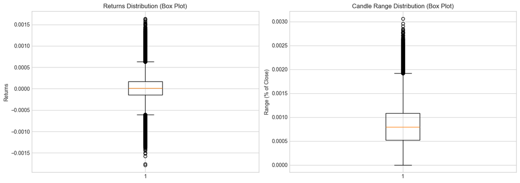

```
⚙️ Capping extreme outliers...
✅ Outliers capped successfully!
```

```python
# ============================================
# 4.3 HANDLING OUTLIERS
# ============================================

print("=" * 60)
print("OUTLIER DETECTION AND HANDLING")
print("=" * 60)

# Calculate returns for outlier detection
df['returns'] = df['close'].pct_change()
df['candle_range'] = (df['high'] - df['low']) / df['close']

# IQR Method for returns
def detect_outliers_iqr(data, column):
    Q1 = data[column].quantile(0.25)
    Q3 = data[column].quantile(0.75)
    IQR = Q3 - Q1
    lower_bound = Q1 - 3 * IQR  # Using 3*IQR for financial data
    upper_bound = Q3 + 3 * IQR
    outliers = ((data[column] < lower_bound) | (data[column] > upper_bound))
    return outliers, lower_bound, upper_bound

# Detect outliers in returns
returns_outliers, ret_lower, ret_upper = detect_outliers_iqr(df, 'returns')
range_outliers, range_lower, range_upper = detect_outliers_iqr(df, 'candle_range')

print(f"\n📊 Returns Outliers: {returns_outliers.sum()} ({returns_outliers.sum()/len(df)*100:.2f}%)")
print(f"📊 Candle Range Outliers: {range_outliers.sum()} ({range_outliers.sum()/len(df)*100:.2f}%)")

# Visualize outliers with box plots
fig, axes = plt.subplots(1, 2, figsize=(14, 5))

# Returns box plot
axes[0].boxplot(df['returns'].dropna(), vert=True)
axes[0].set_title('Returns Distribution (Box Plot)')
axes[0].set_ylabel('Returns')

# Candle range box plot
axes[1].boxplot(df['candle_range'].dropna(), vert=True)
axes[1].set_title('Candle Range Distribution (Box Plot)')
axes[1].set_ylabel('Range (% of Close)')

plt.tight_layout()
plt.show()

# For financial data, we cap outliers instead of removing them
print("\n⚙️ Capping extreme outliers...")
df['returns'] = df['returns'].clip(lower=ret_lower, upper=ret_upper)
df['candle_range'] = df['candle_range'].clip(lower=0, upper=range_upper)

print("✅ Outliers capped successfully!")
```

### 4.4 Feature Engineering - Technical Indicators

Calculate technical indicators including RSI, MACD, Bollinger Bands, ATR, and various price action patterns.

```python
# ============================================
# 4.4 FEATURE ENGINEERING - TECHNICAL INDICATORS
# ============================================

print("=" * 60)
print("FEATURE ENGINEERING - TECHNICAL INDICATORS")
print("=" * 60)

# Make a copy for feature engineering
df_features = df.copy()

# Set datetime as index temporarily for pandas_ta
df_features.set_index('datetime', inplace=True)

print("\n⚙️ Calculating technical indicators...")

# ==========================================
# 1. TREND INDICATORS
# ==========================================
print("   📊 Calculating trend indicators...")

# Simple Moving Averages
df_features['SMA_5'] = ta.sma(df_features['close'], length=5)
df_features['SMA_10'] = ta.sma(df_features['close'], length=10)
df_features['SMA_20'] = ta.sma(df_features['close'], length=20)
df_features['SMA_50'] = ta.sma(df_features['close'], length=50)

# Exponential Moving Averages
df_features['EMA_5'] = ta.ema(df_features['close'], length=5)
df_features['EMA_10'] = ta.ema(df_features['close'], length=10)
df_features['EMA_20'] = ta.ema(df_features['close'], length=20)

# MACD (12, 26, 9)
macd = ta.macd(df_features['close'], fast=12, slow=26, signal=9)
df_features['MACD'] = macd['MACD_12_26_9']
df_features['MACD_signal'] = macd['MACDs_12_26_9']
df_features['MACD_hist'] = macd['MACDh_12_26_9']

# ==========================================
# 2. MOMENTUM INDICATORS
# ==========================================
print("   📊 Calculating momentum indicators...")

# RSI (14-period)
df_features['RSI_14'] = ta.rsi(df_features['close'], length=14)
df_features['RSI_7'] = ta.rsi(df_features['close'], length=7)

# Stochastic Oscillator
stoch = ta.stoch(df_features['high'], df_features['low'], df_features['close'])
df_features['STOCH_K'] = stoch['STOCHk_14_3_3']
df_features['STOCH_D'] = stoch['STOCHd_14_3_3']

# Williams %R
df_features['WILLR'] = ta.willr(df_features['high'], df_features['low'], df_features['close'])

# Rate of Change
df_features['ROC_5'] = ta.roc(df_features['close'], length=5)
df_features['ROC_10'] = ta.roc(df_features['close'], length=10)

# ==========================================
# 3. VOLATILITY INDICATORS
# ==========================================
print("   📊 Calculating volatility indicators...")

# Bollinger Bands (20, 2)
bbands = ta.bbands(df_features['close'], length=20, std=2)
# Dynamically get column names (handles different pandas_ta versions)
bb_cols = bbands.columns.tolist()
bb_upper_col = [c for c in bb_cols if c.startswith('BBU_')][0]
bb_middle_col = [c for c in bb_cols if c.startswith('BBM_')][0]
bb_lower_col = [c for c in bb_cols if c.startswith('BBL_')][0]
df_features['BB_upper'] = bbands[bb_upper_col]
df_features['BB_middle'] = bbands[bb_middle_col]
df_features['BB_lower'] = bbands[bb_lower_col]
df_features['BB_width'] = (df_features['BB_upper'] - df_features['BB_lower']) / df_features['BB_middle']
df_features['BB_pct'] = (df_features['close'] - df_features['BB_lower']) / (df_features['BB_upper'] - df_features['BB_lower'])

# Average True Range (14-period)
df_features['ATR_14'] = ta.atr(df_features['high'], df_features['low'], df_features['close'], length=14)
df_features['ATR_7'] = ta.atr(df_features['high'], df_features['low'], df_features['close'], length=7)

# Standard Deviation
df_features['STD_20'] = df_features['close'].rolling(window=20).std()

# ==========================================
# 4. VOLUME INDICATORS
# ==========================================
print("   📊 Calculating volume indicators...")

# Volume Moving Averages
df_features['VOL_SMA_20'] = df_features['volume'].rolling(window=20).mean()
df_features['VOL_ratio'] = df_features['volume'] / df_features['VOL_SMA_20']

# On-Balance Volume
df_features['OBV'] = ta.obv(df_features['close'], df_features['volume'])

# ==========================================
# 5. PRICE ACTION FEATURES
# ==========================================
print("   📊 Calculating price action features...")

# Candlestick patterns
df_features['body_size'] = abs(df_features['close'] - df_features['open'])
df_features['upper_shadow'] = df_features['high'] - df_features['close'].clip(lower=df_features['open'])
df_features['lower_shadow'] = df_features['open'].clip(upper=df_features['close']) - df_features['low']
df_features['body_ratio'] = df_features['body_size'] / (df_features['high'] - df_features['low'] + 0.0001)

# Bullish/Bearish candle
df_features['is_bullish'] = (df_features['close'] > df_features['open']).astype(int)

# Price position in range
df_features['price_position'] = (df_features['close'] - df_features['low']) / (df_features['high'] - df_features['low'] + 0.0001)

# ==========================================
# 6. LAGGED FEATURES
# ==========================================
print("   📊 Calculating lagged features...")

# Lagged returns
for lag in [1, 2, 3, 5, 10]:
    df_features[f'return_lag_{lag}'] = df_features['close'].pct_change(lag)

# Lagged close prices
for lag in [1, 2, 3]:
    df_features[f'close_lag_{lag}'] = df_features['close'].shift(lag)

# Price distance from moving averages
df_features['dist_SMA_20'] = (df_features['close'] - df_features['SMA_20']) / df_features['SMA_20']
df_features['dist_EMA_10'] = (df_features['close'] - df_features['EMA_10']) / df_features['EMA_10']

# MA Crossover signals
df_features['EMA_cross'] = (df_features['EMA_5'] > df_features['EMA_20']).astype(int)
df_features['SMA_cross'] = (df_features['SMA_5'] > df_features['SMA_20']).astype(int)

print("\n✅ Technical indicators calculated successfully!")
print(f"📊 Total features created: {len(df_features.columns)}")
```

```
============================================================
FEATURE ENGINEERING - TECHNICAL INDICATORS
============================================================

⚙️ Calculating technical indicators...
   📊 Calculating trend indicators...
   📊 Calculating momentum indicators...
   📊 Calculating volatility indicators...
   📊 Calculating volume indicators...
   📊 Calculating price action features...
   📊 Calculating lagged features...

✅ Technical indicators calculated successfully!
📊 Total features created: 53
```

### 4.5 Target Variable Creation

Create binary target variable for 5-pip movement prediction within 5 candles.

```
============================================================
TARGET VARIABLE CREATION
============================================================

📊 Target Configuration:
   Target Movement: 5 pips ($0.50)
   Prediction Horizon: 5 candles

📊 Target Variable Distribution:
   Class 0 (No significant UP movement): 2,352 (0.31%)
   Class 1 (UP movement >= 5 pips): 747,889 (99.69%)
```

[figure not shown]

```
📊 Class Imbalance Ratio: 0.0031
⚠️ Warning: Significant class imbalance detected. Consider using SMOTE or class weights.
```

```python
# ============================================
# 4.5 TARGET VARIABLE CREATION
# ============================================

print("=" * 60)
print("TARGET VARIABLE CREATION")
print("=" * 60)

# Define pip value for XAUUSD (typically 0.01 = 1 pip)
PIP_VALUE = 0.10  # 1 pip = $0.10 for XAUUSD
TARGET_PIPS = 5   # Target movement
HORIZON = 5       # Number of candles to look ahead

target_points = TARGET_PIPS * PIP_VALUE
print(f"\n📊 Target Configuration:")
print(f"   Target Movement: {TARGET_PIPS} pips (${target_points:.2f})")
print(f"   Prediction Horizon: {HORIZON} candles")

# Calculate future maximum high and minimum low within the horizon
df_features['future_max_high'] = df_features['high'].rolling(window=HORIZON).max().shift(-HORIZON)
df_features['future_min_low'] = df_features['low'].rolling(window=HORIZON).min().shift(-HORIZON)

# Calculate potential upside and downside movements
df_features['potential_up'] = df_features['future_max_high'] - df_features['close']
df_features['potential_down'] = df_features['close'] - df_features['future_min_low']

# Create target variables
# Target 1: Price goes UP by 5 pips within 5 candles
df_features['target_up'] = (df_features['potential_up'] >= target_points).astype(int)

# Target 2: Price goes DOWN by 5 pips within 5 candles
df_features['target_down'] = (df_features['potential_down'] >= target_points).astype(int)

# Target 3: Combined - Any significant movement (UP or DOWN)
df_features['target_movement'] = ((df_features['target_up'] == 1) | (df_features['target_down'] == 1)).astype(int)

# Target 4: Direction - 1 for UP, 0 for DOWN, -1 for no movement
# We'll use this as our main target (binary: UP vs NOT UP)
df_features['target'] = df_features['target_up']

# Display target distribution
print("\n📊 Target Variable Distribution:")
target_counts = df_features['target'].value_counts()
print(f"   Class 0 (No significant UP movement): {target_counts.get(0, 0):,} ({target_counts.get(0, 0)/len(df_features)*100:.2f}%)")
print(f"   Class 1 (UP movement >= 5 pips): {target_counts.get(1, 0):,} ({target_counts.get(1, 0)/len(df_features)*100:.2f}%)")

# Visualize target distribution
fig, axes = plt.subplots(1, 2, figsize=(12, 4))

# Pie chart
colors = ['#ff9999', '#66b3ff']
axes[0].pie(target_counts, labels=['No Movement', 'UP Movement'], autopct='%1.1f%%', colors=colors, explode=(0, 0.1))
axes[0].set_title('Target Class Distribution')

# Bar chart
target_counts.plot(kind='bar', ax=axes[1], color=colors)
axes[1].set_title('Target Class Counts')
axes[1].set_xlabel('Class')
axes[1].set_ylabel('Count')
axes[1].set_xticklabels(['No Movement (0)', 'UP Movement (1)'], rotation=0)

plt.tight_layout()
plt.show()

# Check for class imbalance
imbalance_ratio = target_counts.min() / target_counts.max()
print(f"\n📊 Class Imbalance Ratio: {imbalance_ratio:.4f}")
if imbalance_ratio < 0.5:
    print("⚠️ Warning: Significant class imbalance detected. Consider using SMOTE or class weights.")
```

### 4.6 Feature Scaling and Normalization

Apply StandardScaler to normalize features for model compatibility.

```python
# ============================================
# 4.6 DATA CLEANING AND PREPARATION
# ============================================

print("=" * 60)
print("DATA CLEANING AND PREPARATION")
print("=" * 60)

# Reset index
df_features = df_features.reset_index()

# Drop rows with NaN values (from indicator calculations)
initial_len = len(df_features)
df_features = df_features.dropna()
final_len = len(df_features)

print(f"\n📊 Rows removed due to NaN: {initial_len - final_len:,}")
print(f"📊 Final dataset size: {final_len:,} records")

# Select features for modeling
exclude_columns = ['datetime', 'target', 'target_up', 'target_down', 'target_movement',
                   'future_max_high', 'future_min_low', 'potential_up', 'potential_down']

feature_columns = [col for col in df_features.columns if col not in exclude_columns]

print(f"\n📊 Number of features for modeling: {len(feature_columns)}")
print("\n📋 Feature list:")
for i, col in enumerate(feature_columns, 1):
    print(f"   {i:2}. {col}")

# Create feature matrix and target vector
X = df_features[feature_columns].copy()
y = df_features['target'].copy()

print(f"\n📊 Feature matrix shape: {X.shape}")
print(f"📊 Target vector shape: {y.shape}")
```

```
============================================================
DATA CLEANING AND PREPARATION
============================================================

📊 Rows removed due to NaN: 54
📊 Final dataset size: 750,187 records

📊 Number of features for modeling: 53

📋 Feature list:
    1. open
    2. high
    3. low
    4. close
    5. volume
    6. returns
    7. candle_range
    8. SMA_5
    9. SMA_10
   10. SMA_20
   11. SMA_50
   12. EMA_5
   13. EMA_10
   14. EMA_20
   15. MACD
   16. MACD_signal
   17. MACD_hist
   18. RSI_14
   19. RSI_7
   20. STOCH_K
   21. STOCH_D
   22. WILLR
   23. ROC_5
   24. ROC_10
   25. BB_upper
   26. BB_middle
   27. BB_lower
   28. BB_width
   29. BB_pct
   30. ATR_14
```

[output cut: 11 more lines]

```
   42. return_lag_1
   43. return_lag_2
   44. return_lag_3
   45. return_lag_5
   46. return_lag_10
   47. close_lag_1
   48. close_lag_2
   49. close_lag_3
   50. dist_SMA_20
   51. dist_EMA_10
   52. EMA_cross
   53. SMA_cross

📊 Feature matrix shape: (750187, 53)
📊 Target vector shape: (750187,)
```

### 4.7 Train-Test Split

Implement time-series aware train-test split preserving temporal order.

```python
# ============================================
# 4.7 TRAIN-TEST SPLIT
# ============================================

print("=" * 60)
print("TRAIN-TEST SPLIT (TIME-SERIES AWARE)")
print("=" * 60)

# For time series data, we preserve temporal order
# Train: First 80% | Test: Last 20%
train_size = 0.8
split_index = int(len(X) * train_size)

X_train = X.iloc[:split_index]
X_test = X.iloc[split_index:]
y_train = y.iloc[:split_index]
y_test = y.iloc[split_index:]

print(f"\n📊 Training set size: {len(X_train):,} samples ({train_size*100:.0f}%)")
print(f"📊 Test set size: {len(X_test):,} samples ({(1-train_size)*100:.0f}%)")

# Display train/test split dates
train_dates = df_features.iloc[:split_index]['datetime']
test_dates = df_features.iloc[split_index:]['datetime']

print(f"\n📅 Training period: {train_dates.min()} to {train_dates.max()}")
print(f"📅 Testing period: {test_dates.min()} to {test_dates.max()}")

# Check class distribution in train and test sets
print("\n📊 Class Distribution in Training Set:")
print(y_train.value_counts(normalize=True))

print("\n📊 Class Distribution in Test Set:")
print(y_test.value_counts(normalize=True))
```

```
============================================================
TRAIN-TEST SPLIT (TIME-SERIES AWARE)
============================================================

📊 Training set size: 600,149 samples (80%)
📊 Test set size: 150,038 samples (20%)

📅 Training period: 2023-01-02 00:49:00 to 2024-08-06 19:17:00
📅 Testing period: 2024-08-06 19:18:00 to 2024-12-30 23:55:00

📊 Class Distribution in Training Set:
target
1    0.996096
0    0.003904
Name: proportion, dtype: float64

📊 Class Distribution in Test Set:
target
1    1.0
Name: proportion, dtype: float64
```

```python
# ============================================
# FEATURE SCALING
# ============================================

print("=" * 60)
print("FEATURE SCALING")
print("=" * 60)

# Initialize StandardScaler
scaler = StandardScaler()

# Fit on training data only (prevent data leakage)
X_train_scaled = pd.DataFrame(
    scaler.fit_transform(X_train),
    columns=feature_columns,
    index=X_train.index
)

# Transform test data
X_test_scaled = pd.DataFrame(
    scaler.transform(X_test),
    columns=feature_columns,
    index=X_test.index
)

print(f"\n✅ Feature scaling applied successfully!")
print(f"📊 Training set scaled shape: {X_train_scaled.shape}")
print(f"📊 Test set scaled shape: {X_test_scaled.shape}")

# Display scaled statistics
print("\n📊 Scaled Training Data Statistics (first 5 features):")
display(X_train_scaled.iloc[:, :5].describe().round(4))

# Save scaler for later use
import pickle
scaler_path = 'xauusd_scaler.pkl'
with open(scaler_path, 'wb') as f:
    pickle.dump(scaler, f)
print(f"\n✅ Scaler saved to '{scaler_path}'")
```

```
============================================================
FEATURE SCALING
============================================================

✅ Feature scaling applied successfully!
📊 Training set scaled shape: (600149, 53)
📊 Test set scaled shape: (150038, 53)

📊 Scaled Training Data Statistics (first 5 features):
```

|  | open | high | low | close | volume |
| --- | --- | --- | --- | --- | --- |
| count | 600149.0000 | 600149.0000 | 600149.0000 | 600149.0000 | 600149.0000 |
| mean | 0.0000 | -0.0000 | 0.0000 | 0.0000 | 0.0000 |
| std | 1.0000 | 1.0000 | 1.0000 | 1.0000 | 1.0000 |
| min | -0.6016 | -0.6016 | -0.6016 | -0.6016 | -1.7519 |
| 25% | -0.5885 | -0.5885 | -0.5885 | -0.5885 | -0.6759 |
| 50% | -0.5003 | -0.5003 | -0.5003 | -0.5003 | -0.3928 |
| 75% | 0.1131 | 0.1131 | 0.1131 | 0.1131 | 0.5416 |
| max | 3.9562 | 3.9565 | 3.9553 | 3.9562 | 4.9304 |

```
✅ Scaler saved to 'xauusd_scaler.pkl'
```

```python
# ============================================
# FEATURE SCALING
# ============================================

print("=" * 60)
print("FEATURE SCALING")
print("=" * 60)

# Initialize scalers
scaler = StandardScaler()

# Fit scaler ONLY on training data to prevent data leakage
X_train_scaled = scaler.fit_transform(X_train)
X_test_scaled = scaler.transform(X_test)

# Convert back to DataFrame for easier manipulation
X_train_scaled = pd.DataFrame(X_train_scaled, columns=feature_columns, index=X_train.index)
X_test_scaled = pd.DataFrame(X_test_scaled, columns=feature_columns, index=X_test.index)

print("\n✅ Feature scaling completed!")
print(f"📊 Scaled training data shape: {X_train_scaled.shape}")
print(f"📊 Scaled test data shape: {X_test_scaled.shape}")

# Display scaled data statistics
print("\n📊 Scaled Training Data Statistics:")
display(X_train_scaled.describe().round(4))

# Save scaler for deployment
import joblib
joblib.dump(scaler, 'xauusd_scaler.pkl')
print("\n✅ Scaler saved to 'xauusd_scaler.pkl' for deployment")
```

```
============================================================
FEATURE SCALING
============================================================

✅ Feature scaling completed!
📊 Scaled training data shape: (600149, 53)
📊 Scaled test data shape: (150038, 53)

📊 Scaled Training Data Statistics:
```

|  | open | high | low | close | volume | returns | candle_range | SMA_5 | SMA_10 | SMA_20 | SMA_50 | EMA_5 | EMA_10 | EMA_20 | MACD | MACD_signal | MACD_hist | RSI_14 | RSI_7 | STOCH_K | STOCH_D | WILLR | ROC_5 | ROC_10 | BB_upper | BB_middle | BB_lower | BB_width | BB_pct | … |
| --- | --- | --- | --- | --- | --- | --- | --- | --- | --- | --- | --- | --- | --- | --- | --- | --- | --- | --- | --- | --- | --- | --- | --- | --- | --- | --- | --- | --- | --- | --- |
| count | 600149.0000 | 600149.0000 | 600149.0000 | 600149.0000 | 600149.0000 | 600149.0000 | 600149.0000 | 600149.0000 | 600149.0000 | 600149.0000 | 600149.0000 | 600149.0000 | 600149.0000 | 600149.0000 | 600149.0000 | 600149.0000 | 600149.0000 | 600149.0000 | 600149.0000 | 600149.0000 | 600149.0000 | 600149.0000 | 600149.0000 | 600149.0000 | 600149.0000 | 600149.0000 | 600149.0000 | 600149.0000 | 600149.0000 | … |
| mean | 0.0000 | -0.0000 | 0.0000 | 0.0000 | 0.0000 | 0.0000 | 0.0000 | 0.0000 | -0.0000 | 0.0000 | -0.0000 | -0.0000 | -0.0000 | -0.0000 | 0.0000 | 0.0000 | 0.0000 | 0.0000 | -0.0000 | 0.0000 | -0.0000 | 0.0000 | -0.0000 | -0.0000 | -0.0000 | 0.0000 | -0.0000 | -0.0000 | -0.0000 | … |
| std | 1.0000 | 1.0000 | 1.0000 | 1.0000 | 1.0000 | 1.0000 | 1.0000 | 1.0000 | 1.0000 | 1.0000 | 1.0000 | 1.0000 | 1.0000 | 1.0000 | 1.0000 | 1.0000 | 1.0000 | 1.0000 | 1.0000 | 1.0000 | 1.0000 | 1.0000 | 1.0000 | 1.0000 | 1.0000 | 1.0000 | 1.0000 | 1.0000 | 1.0000 | … |
| min | -0.6016 | -0.6016 | -0.6016 | -0.6016 | -1.7519 | -4.3508 | -2.0604 | -0.6016 | -0.6016 | -0.6016 | -0.6016 | -0.6016 | -0.6016 | -0.6016 | -11.3022 | -10.6532 | -12.5969 | -3.5373 | -2.7958 | -2.3570 | -2.3656 | -2.2824 | -5.0987 | -4.5425 | -0.6016 | -0.6016 | -0.6016 | -1.8345 | -3.1905 | … |
| 25% | -0.5885 | -0.5885 | -0.5885 | -0.5885 | -0.6759 | -0.6242 | -0.7518 | -0.5885 | -0.5885 | -0.5885 | -0.5885 | -0.5885 | -0.5885 | -0.5885 | -0.1549 | -0.1617 | -0.0476 | -0.7007 | -0.7346 | -0.8456 | -0.8448 | -0.8352 | -0.6611 | -0.6686 | -0.5885 | -0.5885 | -0.5885 | -0.7351 | -0.8309 | … |
| 50% | -0.5003 | -0.5003 | -0.5003 | -0.5003 | -0.3928 | -0.0031 | -0.0635 | -0.5003 | -0.5003 | -0.5003 | -0.5003 | -0.5003 | -0.5003 | -0.5003 | -0.1377 | -0.1454 | 0.0001 | 0.0148 | 0.0222 | 0.0796 | 0.0777 | 0.0733 | -0.0035 | -0.0011 | -0.5003 | -0.5003 | -0.5003 | -0.2136 | 0.1026 | … |
| 75% | 0.1131 | 0.1131 | 0.1131 | 0.1131 | 0.5416 | 0.6190 | 0.6656 | 0.1131 | 0.1131 | 0.1130 | 0.1131 | 0.1131 | 0.1131 | 0.1130 | -0.0297 | -0.0323 | 0.0467 | 0.7183 | 0.7537 | 0.8625 | 0.8625 | 0.8513 | 0.6575 | 0.6660 | 0.1130 | 0.1130 | 0.1131 | 0.5193 | 0.8229 | … |
| max | 3.9562 | 3.9565 | 3.9553 | 3.9562 | 4.9304 | 4.3472 | 4.9172 | 3.9550 | 3.9543 | 3.9540 | 3.9535 | 3.9549 | 3.9544 | 3.9537 | 11.3301 | 11.5346 | 12.3359 | 3.1588 | 2.5187 | 2.0712 | 2.0396 | 1.9808 | 5.5825 | 5.1015 | 3.9523 | 3.9540 | 3.9560 | 6.6663 | 2.8395 | … |

```
✅ Scaler saved to 'xauusd_scaler.pkl' for deployment
```

## 5. Data Visualization

### 5.1 Basic Visualizations

Price charts, histograms, and distribution analysis.

```
============================================================
DATA VISUALIZATION - PRICE ANALYSIS
============================================================
```

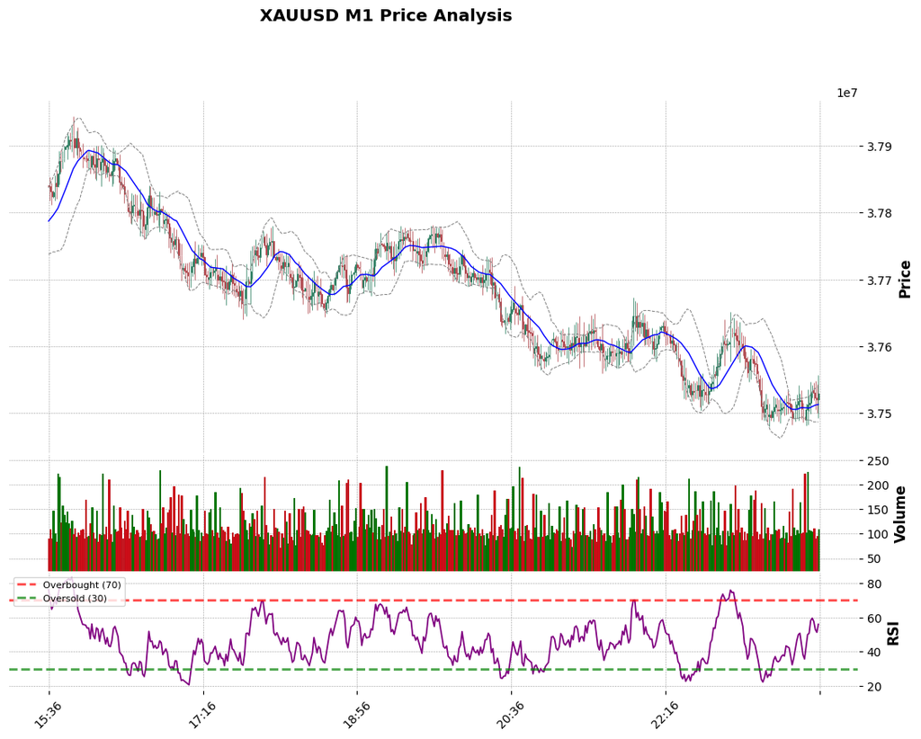

```
✅ Price chart visualization completed!
```

```python
# ============================================
# 5.1 PRICE CHART VISUALIZATION
# ============================================

import mplfinance as mpf

print("=" * 60)
print("DATA VISUALIZATION - PRICE ANALYSIS")
print("=" * 60)

# Sample data for visualization (last 500 candles for better visibility)
sample_data = df_features.tail(500).copy()
sample_data.set_index('datetime', inplace=True)

# Create the candlestick chart with indicators using mplfinance
# Add Bollinger Bands and SMA as additional plots
ap = [
    mpf.make_addplot(sample_data['BB_upper'], color='gray', linestyle='--', width=0.7),
    mpf.make_addplot(sample_data['BB_lower'], color='gray', linestyle='--', width=0.7),
    mpf.make_addplot(sample_data['SMA_20'], color='blue', width=1),
    mpf.make_addplot(sample_data['RSI_14'], panel=2, color='purple', ylabel='RSI'),
]

# Plot with mplfinance
fig, axes = mpf.plot(sample_data,
                      type='candle',
                      style='charles',
                      title='XAUUSD M1 Price Analysis',
                      ylabel='Price',
                      volume=True,
                      addplot=ap,
                      figsize=(14, 10),
                      panel_ratios=(6, 2, 2),
                      returnfig=True)

# Add RSI overbought/oversold lines
axes[4].axhline(y=70, color='red', linestyle='--', alpha=0.7, label='Overbought (70)')
axes[4].axhline(y=30, color='green', linestyle='--', alpha=0.7, label='Oversold (30)')
axes[4].legend(loc='upper left', fontsize=8)

plt.tight_layout()
plt.show()

print("\n✅ Price chart visualization completed!")
```

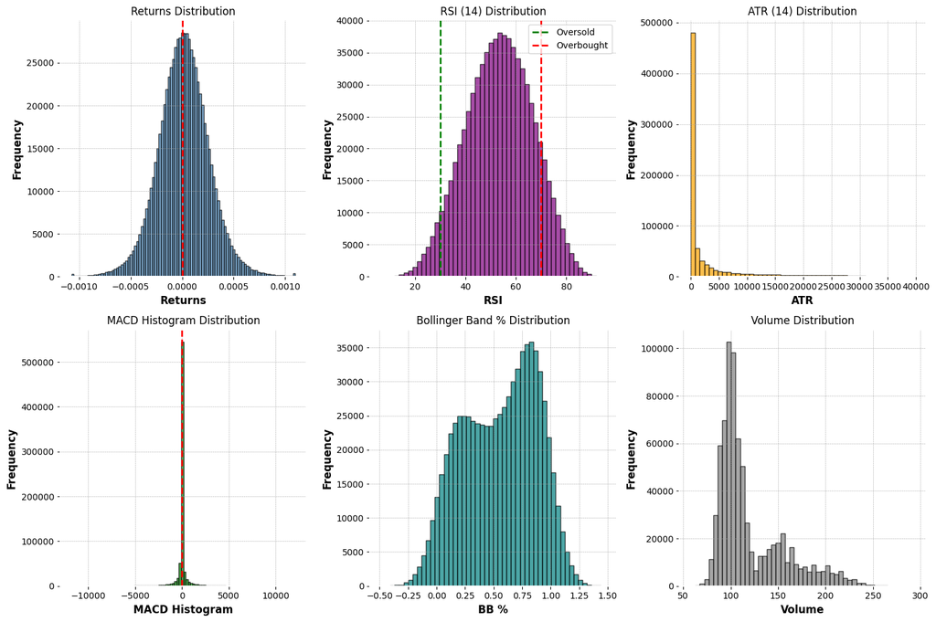

```
✅ Histogram visualizations saved to 'histograms.png'
```

```python
# ============================================
# 5.1 HISTOGRAM AND DISTRIBUTION ANALYSIS
# ============================================

fig, axes = plt.subplots(2, 3, figsize=(15, 10))

# Returns distribution
axes[0, 0].hist(df_features['returns'].dropna(), bins=100, color='steelblue', alpha=0.7, edgecolor='black')
axes[0, 0].set_title('Returns Distribution')
axes[0, 0].set_xlabel('Returns')
axes[0, 0].set_ylabel('Frequency')
axes[0, 0].axvline(x=0, color='red', linestyle='--')

# RSI distribution
axes[0, 1].hist(df_features['RSI_14'].dropna(), bins=50, color='purple', alpha=0.7, edgecolor='black')
axes[0, 1].set_title('RSI (14) Distribution')
axes[0, 1].set_xlabel('RSI')
axes[0, 1].set_ylabel('Frequency')
axes[0, 1].axvline(x=30, color='green', linestyle='--', label='Oversold')
axes[0, 1].axvline(x=70, color='red', linestyle='--', label='Overbought')
axes[0, 1].legend()

# ATR distribution
axes[0, 2].hist(df_features['ATR_14'].dropna(), bins=50, color='orange', alpha=0.7, edgecolor='black')
axes[0, 2].set_title('ATR (14) Distribution')
axes[0, 2].set_xlabel('ATR')
axes[0, 2].set_ylabel('Frequency')

# MACD histogram distribution
axes[1, 0].hist(df_features['MACD_hist'].dropna(), bins=100, color='green', alpha=0.7, edgecolor='black')
axes[1, 0].set_title('MACD Histogram Distribution')
axes[1, 0].set_xlabel('MACD Histogram')
axes[1, 0].set_ylabel('Frequency')
axes[1, 0].axvline(x=0, color='red', linestyle='--')

# Bollinger Band % distribution
axes[1, 1].hist(df_features['BB_pct'].dropna(), bins=50, color='teal', alpha=0.7, edgecolor='black')
axes[1, 1].set_title('Bollinger Band % Distribution')
axes[1, 1].set_xlabel('BB %')
axes[1, 1].set_ylabel('Frequency')

# Volume distribution
axes[1, 2].hist(df_features['volume'].dropna(), bins=50, color='gray', alpha=0.7, edgecolor='black')
axes[1, 2].set_title('Volume Distribution')
axes[1, 2].set_xlabel('Volume')
axes[1, 2].set_ylabel('Frequency')

plt.tight_layout()
plt.savefig('histograms.png', dpi=150, bbox_inches='tight')
plt.show()

print("\n✅ Histogram visualizations saved to 'histograms.png'")
```

### 5.2 Correlation Heatmap

Analyze correlations between features and identify highly correlated variables.

```
============================================================
CORRELATION ANALYSIS
============================================================
```

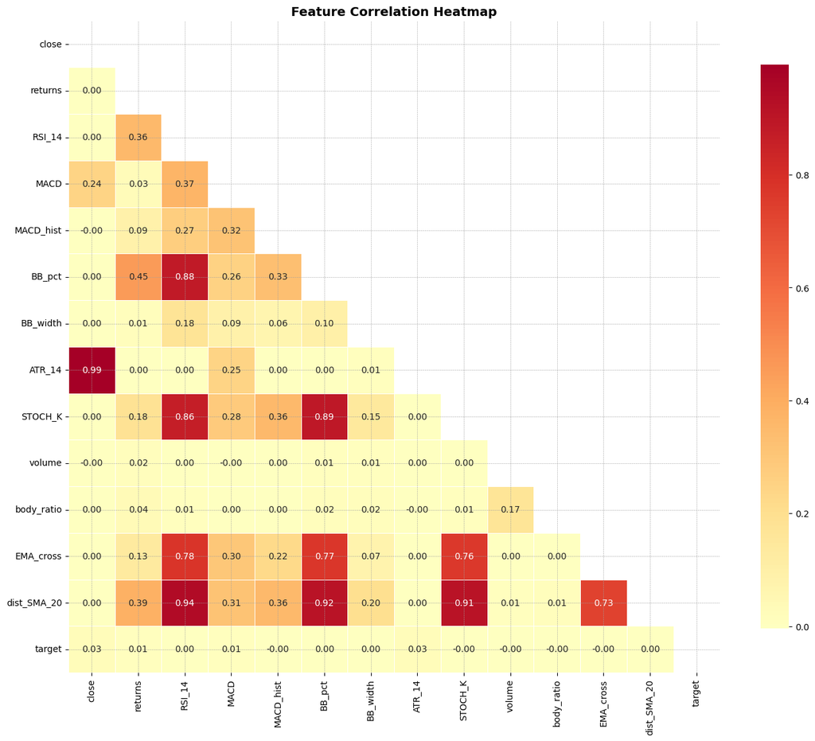

```
📊 Top Features Correlated with Target:
   1. close: 0.0269
   2. ATR_14: 0.0268
   3. returns: 0.0070
   4. MACD: 0.0069
   5. BB_pct: 0.0024
   6. dist_SMA_20: 0.0019
   7. RSI_14: 0.0019
   8. BB_width: 0.0008
   9. EMA_cross: 0.0005
   10. body_ratio: 0.0004

⚠️ Highly Correlated Feature Pairs (>0.8):
   close - ATR_14: 0.9946
   RSI_14 - BB_pct: 0.8831
   RSI_14 - STOCH_K: 0.8627
   RSI_14 - dist_SMA_20: 0.9411
   BB_pct - STOCH_K: 0.8880
   BB_pct - dist_SMA_20: 0.9159
   STOCH_K - dist_SMA_20: 0.9120
```

```python
# ============================================
# 5.2 CORRELATION HEATMAP
# ============================================

print("=" * 60)
print("CORRELATION ANALYSIS")
print("=" * 60)

# Select key features for correlation analysis
key_features = ['close', 'returns', 'RSI_14', 'MACD', 'MACD_hist', 'BB_pct', 'BB_width',
                'ATR_14', 'STOCH_K', 'volume', 'body_ratio', 'EMA_cross', 'dist_SMA_20']

# Calculate correlation matrix
corr_matrix = df_features[key_features + ['target']].corr()

# Create heatmap
plt.figure(figsize=(14, 12))
mask = np.triu(np.ones_like(corr_matrix, dtype=bool))
sns.heatmap(corr_matrix, mask=mask, annot=True, cmap='RdYlBu_r', center=0,
            fmt='.2f', square=True, linewidths=0.5,
            cbar_kws={"shrink": 0.8})
plt.title('Feature Correlation Heatmap', fontsize=14, fontweight='bold')
plt.tight_layout()
plt.savefig('correlation_heatmap.png', dpi=150, bbox_inches='tight')
plt.show()

# Feature-Target correlations
print("\n📊 Top Features Correlated with Target:")
target_corr = corr_matrix['target'].drop('target').abs().sort_values(ascending=False)
for i, (feature, corr) in enumerate(target_corr.head(10).items(), 1):
    print(f"   {i}. {feature}: {corr:.4f}")

# Identify highly correlated features (potential multicollinearity)
print("\n⚠️ Highly Correlated Feature Pairs (>0.8):")
high_corr_pairs = []
for i in range(len(corr_matrix.columns)):
    for j in range(i+1, len(corr_matrix.columns)):
        if abs(corr_matrix.iloc[i, j]) > 0.8:
            high_corr_pairs.append((corr_matrix.columns[i], corr_matrix.columns[j], corr_matrix.iloc[i, j]))

for pair in high_corr_pairs:
    print(f"   {pair[0]} - {pair[1]}: {pair[2]:.4f}")
```